# HW 6

SDS322E

2021-10-07

## Vaishnavi Sathiyamoorthy vs25229

**Please submit as a knitted HTML file on Canvas before the due date.**

*For all questions, include the R commands/functions that you used to find your answer. Answers without supporting code will not receive credit.*

> **Review of how to submit this assignment** All homework assignments will be completed using R Markdown. These `.Rmd` files consist of text/syntax (formatted using Markdown) alongside embedded R code. When you have completed the assignment (by adding R code inside codeblocks and supporting text outside of the codeblocks), create your document as follows:
> - Click the arrow next to the “Knit” button (above)
> - Choose “Knit to HTML”
> - Go to Files pane and put checkmark next to the correct HTML file
> - Click on the blue gear icon (“More”) and click Export
> - Download the file and then upload to Canvas

## Question 1:

##### Load the package nycflights13 with library(nycflights13). If you are not on the servers, you will need to install this package before you can use it!

##### Run the included code chunk below to save flights and airports to your environment.

```r
# install.packages('nycflights13')
library(nycflights13)
library(tidyverse)

flights <- flights
airports <- airports
airlines <- airlines
```

##### Explore the `flights` dataset (e.g., run `glimpse(flights)` read the description of each variable in the help by running `?flights`). Notice how many rows/observations there are: That’s how many flights left the three big NYC airports in 2013!

### 1.1 (2 pts)

##### Report the number and proportion of NAs for each variable using summarize_all() and/or mutate_all(). Ideally, you will write your own short function(s) to count NAs and apply it to every column via `summarize_all`, but there are other ways.

```r
flights %>%
    summarise_all(function(x) sum(is.na(x)))
```

```
## # A tibble: 1 × 19
##    year month   day dep_time sched_dep_time dep_delay arr_time sched_arr_time
##   <int> <int> <int>    <int>          <int>     <int>    <int>          <int>
## 1     0     0     0     8255              0      8255     8713              0
## # ℹ 11 more variables: arr_delay <int>, carrier <int>, flight <int>,
## #   tailnum <int>, origin <int>, dest <int>, air_time <int>, distance <int>,
## #   hour <int>, minute <int>, time_hour <int>
```

### 1.2 (2 pts)

##### Remove all rows containing NAs from the dataset (**for the rest of the assignment, we will be using only the complete rows, so overwrite the `flights` dataset or save it as a new object and use it in place of `flights` from here on out**). Now, using filter, what airport `dest`ination (three-letter code fine) has the longest `air_time`?

```r
flights <- flights %>%
    na.omit()
flights %>%
    group_by(dest) %>%
    summarise(mean_airtime = mean(air_time)) %>%
    arrange(desc(mean_airtime))
```

```
## # A tibble: 104 × 2
##    dest  mean_airtime
##    <chr>        <dbl>
##  1 HNL           617.
##  2 ANC           413.
##  3 SJC           347.
##  4 SFO           346.
##  5 OAK           345.
##  6 SMF           336.
##  7 BUR           334.
##  8 PSP           333.
##  9 PDX           330.
## 10 LGB           330.
## # ℹ 94 more rows
```

### 1.3 (4 pts)

##### Find the mean, standard deviation, count, and standard error of `distance` in each month (i.e., averaged across `day`) for flights from the three different New York airports (`origin`). You will use your sd and count to find your se=sd/sqrt(count). Rename your summary variables inside of `summarize()`.

```r
flights %>%
    group_by(month, origin) %>%
    summarise(mean_dist = mean(distance), num_dist = n(),
        sd_dist = sd(distance), se = sd_dist/sqrt(num_dist))
```

```
## # A tibble: 36 × 6
## # Groups:   month [12]
##    month origin mean_dist num_dist sd_dist    se
##    <int> <chr>      <dbl>    <int>   <dbl> <dbl>
##  1     1 EWR         970.     9616    692.  7.05
##  2     1 JFK        1241.     9031    896.  9.43
##  3     1 LGA         802.     7751    371.  4.21
##  4     2 EWR         964.     8575    682.  7.36
##  5     2 JFK        1234.     8007    887.  9.91
##  6     2 LGA         802.     7029    373.  4.45
##  7     3 EWR         988.    10015    673.  6.72
##  8     3 JFK        1256.     9497    879.  9.01
##  9     3 LGA         800.     8390    372.  4.06
## 10     4 EWR        1052.    10231    720.  7.12
## 11     4 JFK        1282.     9013    889.  9.37
```

[output cut: 25 more lines]

### 1.4 (4 pts)

##### Using your results from part 1.3, make a barplot of mean distance for each month using `ggplot()`. Add manual standard error bars using geom_errorbar() by specifying `aes(x=month, y=your_mean, ymin=your_mean-your_se, ymax=your_mean+your_se)`. Facet (or equivalent) by `origin` and provide labels/ticks on the x-axis for each month. Write a bit about what you see!

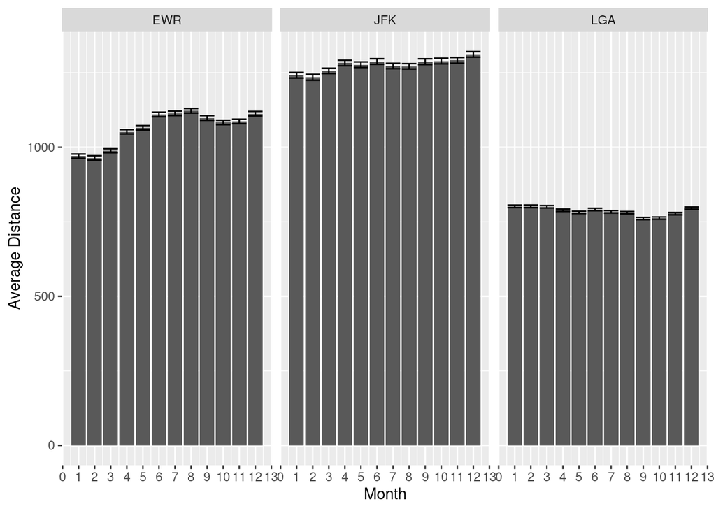

```r
flights %>%
    group_by(month, origin) %>%
    summarise(mean_dist = mean(distance), num_dist = n(),
        sd_dist = sd(distance), se = sd_dist/sqrt(num_dist)) %>%
    ggplot(aes(x = month, y = mean_dist)) + geom_bar(stat = "identity") +
    facet_grid(~origin) + xlab("Month") + ylab("Average Distance") +
    scale_x_continuous(n.breaks = 12) + geom_errorbar(aes(x = month,
    y = mean_dist, ymin = mean_dist - se, ymax = mean_dist +
        se))
```

*The average distance travelled throughout the year is consistent within each airport. However, the average distance traveled at JFK is higher than EWR and LGA. The standard error is also smaller at LGA.*

## Question 2 (2 pts)

Let’s do some joining! The dataset `airlines` contains the full name of the carrier (examine it!). Join the dataset with the flights dataset so all of the information in `flights` is retained. Using the merged dataset, which carrier (`name`) has the longest average departure delay? Which has the shortest?

```r
joined_airlines_flights <- left_join(flights, airlines,
    by = "carrier")
joined_airlines_flights %>%
    group_by(name) %>%
    summarise(mean_dep_delay = mean(dep_delay)) %>%
    arrange(mean_dep_delay)
```

```
## # A tibble: 16 × 2
##    name                        mean_dep_delay
##    <chr>                                <dbl>
##  1 US Airways Inc.                       3.74
##  2 Hawaiian Airlines Inc.                4.90
##  3 Alaska Airlines Inc.                  5.83
##  4 American Airlines Inc.                8.57
##  5 Delta Air Lines Inc.                  9.22
##  6 Envoy Air                            10.4
##  7 United Air Lines Inc.                12.0
##  8 SkyWest Airlines Inc.                12.6
##  9 Virgin America                       12.8
## 10 JetBlue Airways                      13.0
## 11 Endeavor Air Inc.                    16.4
## 12 Southwest Airlines Co.               17.7
## 13 AirTran Airways Corporation          18.6
## 14 Mesa Airlines Inc.                   18.9
## 15 ExpressJet Airlines Inc.             19.8
## 16 Frontier Airlines Inc.               20.2
```

*Frontier has the longest average departure delay and US Airways has the shortest average departure delay.*

## Question 3

### 3.1 (4 pts)

##### Look at the dataset called `airports`. How many rows does it have? How many unique airports (variable `faa`)? Using methods we have seen/discussed (e.g., `%in%` with `sum()` or `mean()`, set operations, joins), how many of these airports (variable `faa`) appear in the `flights` dataset as destinations (variable `dest`)? How many unique destination airports are there in the flights dataset? Which destination airports are in the `flights` dataset but missing from the `airports` dataset? Google those airport codes: what do they have in common?

```r
count(airports)
```

```
## # A tibble: 1 × 1
##       n
##   <int>
## 1  1458
```

```r
airports %>%
    summarize_all(n_distinct) %>%
    pull(faa)
```

```
## [1] 1458
```

```r
distinct_airports <- airports %>%
    distinct(faa)
distinct_flights <- flights %>%
    distinct(dest)
count(semi_join(distinct_airports, distinct_flights,
    by = c(faa = "dest")))
```

```
## # A tibble: 1 × 1
##       n
##   <int>
## 1   100
```

```r
flights %>%
    summarize_all(n_distinct) %>%
    pull(dest)
```

```
## [1] 104
```

```r
anti_join(distinct_flights, distinct_airports, by = c(dest = "faa"))
```

```
## # A tibble: 4 × 1
##   dest
##   <chr>
## 1 BQN
## 2 SJU
## 3 STT
## 4 PSE
```

*There are 1458 rows in the airports dataset. There are 1458 unique airports in the airports dataset. 100 of the airports in the airports dataset appears in the flights dataset. There are 104 unique destinations in the flights dataset. BQN, SJU, STT, and PSE appear in the flights dataset, but not in the airports dataset. Three of those were in Puerto Rico and one of those were in the Virgin Islands. The common factor is that these are overseas US territories.*

### 3.2 (2 pts)

##### Do a join that results in a dataset that contains only the rows with matches (i.e., none of the airports not appearing in `flights`, none of the destinations not appearing in `airports`). Call `glimpse()` on this final dataset (please don’t print the whole thing out).

```r
semi_join(distinct_airports, distinct_flights, by = c(faa = "dest")) %>%
    glimpse
```

```
## Rows: 100
## Columns: 1
## $ faa <chr> "ABQ", "ACK", "ALB", "ANC", "ATL", "AUS", "AVL", "BDL", "BGR", "BH…
```

[output not shown]

[output not shown]